# Predictors of Absolute VO2max

Dawson Shero

2026-09-25

# Setup

## Combine Raw Data Files

This step was run once to combine the individual Excel files into `combined_tests.csv` and is not re-run after.

# Data Cleaning

```r
df_raw <- read.csv(here("data", "combined_tests.csv"))

df_raw <- df_raw |>
  rename(file = "source_file")

df_raw_sum <- read.csv(here("data", "Data_Summary_with_age.csv"))

df_raw_sum <- df_raw_sum |>
  select("file", "age")

df_raw <- df_raw |>
  group_by(file) |>
  mutate(max_bla = max(bla))

### Making a df that only has variables that are needed for the study

colnames(df_raw)

df_clean <- df_raw |>
  select("file", "gender", "event", "test", "height", "weight", "bmi", "fat", "lbm", "hb",
         "hct", "rbc", "wbc", "max_bla", "vo2max", "vo2max_absolute", "hrmax", "load_tlac",
         "hr_tlac", "percent_vo2max_tlac", "percent_h_rmax_tlac", "bla_tlac")

df_clean <- merge(df_clean, df_raw_sum, by = "file")

df_clean <- df_clean |>
  relocate("age", .after = gender)

df_clean <- df_clean |>
  distinct(file, .keep_all = T)

df_clean <- df_clean |>
  filter(!file %in% c("A539.xlsx", "A140.xlsx", "A562.xlsx", "A1065.xlsx"))

### Df manipulation and cleaning for analysis
colnames(df_clean)

anyNA(df_clean)

colSums(is.na(df_clean))

df_clean$weight[df_clean$weight == "Missing"] <- NA

df_clean <- df_clean |>
  na.omit() |>
  mutate(weight = as.numeric(as.character(weight)))

df_clean <- df_clean |>
  mutate(across(where(is.numeric), ~ round(., 2)))

df_clean <- df_clean |>
  filter(age >= 18)

df_clean <- df_clean |>
  rename(sex = gender)

df_clean <- df_clean %>%
  mutate(test = case_match(test,
    c("Rowing", "Kayak") ~ "watersports",
    .default = test
  ))

df_clean <- df_clean |>
  mutate(age_cat = case_when(
    age < 20             ~ "<20",
    age >= 20 & age < 30  ~ "20-29",
    age >= 30 & age < 40  ~ "30-39",
    age >= 40 & age < 50  ~ "40-49",
    age >= 50 & age < 60  ~ "50-59",
    age >= 60 & age < 70  ~ "60-69",
    age >= 70             ~ "70+",
    TRUE ~ NA_character_
  )) |>
  mutate(age_cat = factor(age_cat,
                           levels = c("<20", "20-29", "30-39", "40-49",
                                      "50-59", "60-69", "70+"),
                           ordered = TRUE)) |>
  relocate(age_cat, .after = age)
```

**Cleaning notes**

- Four participants (A539, A140, A562, A1065) were excluded because of implausible or irreconcilable values (VO2max, body fat %, hematocrit).
- Participants under 18 or with missing values were removed, and rowing and kayak were combined into “watersports”.
- Blood lactate(bla) used max() function due to bla being linked to max effort in GxT
- Final analytic sample: **N = 699** (147 women, 552 men).

# Descriptive Statistics

```r
# Overall
df_clean |>
  summarise(
    n = n(),
    age_mean = mean(age),
    age_sd = sd(age),
    abs_vo2_mean = mean(vo2max_absolute),
    abs_vo2_sd = sd(vo2max_absolute)
  ) |>
  knitr::kable(digits = 2, caption = "Overall sample")
```

Overall sample

| n | age_mean | age_sd | abs_vo2_mean | abs_vo2_sd |
| --- | --- | --- | --- | --- |
| 699 | 27.56 | 7 | 4.61 | 0.86 |

```r
# By modality
df_clean |>
  group_by(test) |>
  summarise(
    n = n(),
    age_mean = mean(age),
    age_sd = sd(age),
    abs_vo2_mean = mean(vo2max_absolute),
    abs_vo2_sd = sd(vo2max_absolute),
    .groups = "drop"
  ) |>
  knitr::kable(digits = 2, caption = "By modality")
```

By modality

| test | n | age_mean | age_sd | abs_vo2_mean | abs_vo2_sd |
| --- | --- | --- | --- | --- | --- |
| Cycling | 247 | 30.38 | 6.93 | 4.58 | 0.74 |
| Running | 225 | 29.37 | 6.89 | 4.26 | 0.88 |
| watersports | 227 | 22.68 | 3.98 | 4.99 | 0.81 |

```r
# By sex
df_clean |>
  group_by(sex) |>
  summarise(
    n = n(),
    age_mean = mean(age),
    age_sd = sd(age),
    abs_vo2_mean = mean(vo2max_absolute),
    abs_vo2_sd = sd(vo2max_absolute),
    .groups = "drop"
  ) |>
  knitr::kable(digits = 2, caption = "By sex")
```

By sex

| sex | n | age_mean | age_sd | abs_vo2_mean | abs_vo2_sd |
| --- | --- | --- | --- | --- | --- |
| F | 147 | 28.24 | 6.07 | 3.40 | 0.49 |
| M | 552 | 27.37 | 7.22 | 4.93 | 0.62 |

```r
# By Age
df_clean |>
  group_by(age_cat) |>
  summarise(
    n = n(),
    age_mean = mean(age),
    age_sd = sd(age),
    abs_vo2_mean = mean(vo2max_absolute),
    abs_vo2_sd = sd(vo2max_absolute),
    .groups = "drop"
  ) |>
  knitr::kable(digits = 2, caption = "By age")
```

By age

| age_cat | n | age_mean | age_sd | abs_vo2_mean | abs_vo2_sd |
| --- | --- | --- | --- | --- | --- |
| <20 | 87 | 18.57 | 0.50 | 4.81 | 0.75 |
| 20-29 | 364 | 24.38 | 2.96 | 4.71 | 0.88 |
| 30-39 | 202 | 33.70 | 2.60 | 4.35 | 0.84 |
| 40-49 | 45 | 42.22 | 2.18 | 4.58 | 0.74 |
| 60-69 | 1 | 65.00 | NA | 3.23 | NA |

```r
# Check that there are enough participants in each moderator group
df_clean |>
  count(sex) |>
  mutate(percent = round(n / sum(n) * 100, 2)) |>
  knitr::kable(caption = "Sex distribution")
```

Sex distribution

| sex | n | percent |
| --- | --- | --- |
| F | 147 | 21.03 |
| M | 552 | 78.97 |

```r
df_clean |>
  count(test) |>
  mutate(percent = round(n / sum(n) * 100, 2)) |>
  knitr::kable(caption = "Modality distribution")
```

Modality distribution

| test | n | percent |
| --- | --- | --- |
| Cycling | 247 | 35.34 |
| Running | 225 | 32.19 |
| watersports | 227 | 32.47 |

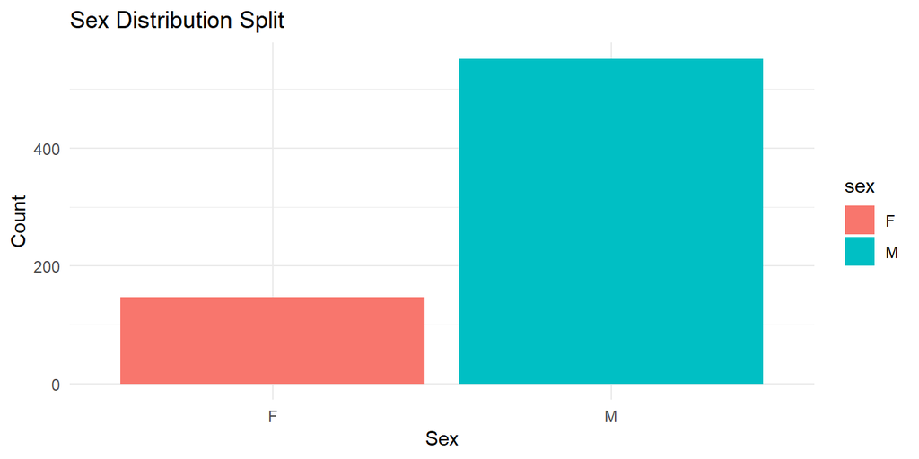

```r
ggplot(df_clean, aes(x = sex, fill = sex)) +
  geom_bar() +
  labs(title = "Sex Distribution Split", y = "Count", x = "Sex") +
  theme_minimal()
```

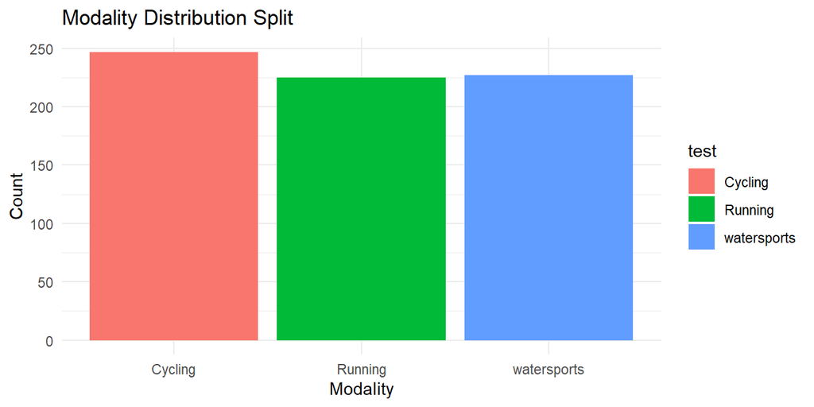

```r
ggplot(df_clean, aes(x = test, fill = test)) +
  geom_bar() +
  labs(title = "Modality Distribution Split", y = "Count", x = "Modality") +
  theme_minimal()
```